# Proyecto1

CarlaChavez

14/2/2022

# **Caso N° 1: Siniestros en Seguros**

Se tiene un conjunto de datos simulado basado en seis meses de la información recogida por una aseguradora mundial llamada **“VIDA SEGUROS”**, cuyo objetivo fue desarrollar un modelo para determinar la probabilidad de siniestro en los próximos 12 meses. La variable de destino es la siniestralidad, que representa el estado binario de No Siniestro 0 y Siniestro 1.

Descripción de las Variables:

Cliente_ID: Identificador de cliente. Antigüedad_Maxima: Antigüedad del cliente en meses. Nivel_Ingresos: Nivel de ingresos de 0 (bajo) a 5 (alto). Saldo_Pendiente: Saldo pendiente del cliente. Puntaje_Morosidad: Tasa de morosidad en el seguro. O: No Dq., 1: 1-29, …, 6: 150-179. Saldo_Pendiente_Seg: Saldo pendiente de la póliza del seguro. Siniestros: Número de siniestros en la historia del cliente. Estado_Siniestro:** 0: No Siniestro, 1: Siniestro.

# Direccionando la carptea de trabajo

```r
getwd()
```

```
## [1] "C:/DISCO_CARLA/CURSOS/2022-Curso_R_ Estadistica/PROYECTO"
```

```r
setwd("C:/DISCO_CARLA/CURSOS/2022-Curso_R_ Estadistica/PROYECTO")
```

```r
data_seguros <- read.csv("Data_Siniestros en Seguros .csv", stringsAsFactors = TRUE, sep=",")
```

```r
View(data_seguros)
```

```r
head(data_seguros)
```

```
##   Cliente_ID Antigüedad_Maxima Nivel_Ingresos Saldo_Pendiente
## 1        185                44              1          604.86
## 2        238                79              1         1006.21
## 3        346               102              1          299.23
## 4        460                NA              1          645.19
## 5        549               109             NA          218.00
## 6        559               183             NA           10.32
##   Puntaje_Morosidad1 Puntaje_Morosidad2 Puntaje_Morosidad3 Puntaje_Morosidad4
## 1                  0                  0                  0                  0
## 2                  0                  0                  0                  0
## 3                  0                  0                  0                  0
## 4                  0                  0                  0                  0
## 5                  0                  0                  0                  0
## 6                  0                  0                  0                  0
##   Puntaje_Morosidad5 Puntaje_Morosidad6 Saldo_Pendiente_Seg Siniestros1
## 1                  0                  0                   0           0
## 2                  0                  0                   0           0
## 3                  0                  0                   0           0
## 4                  0                  0                   0           0
## 5                  0                  0                   0           0
## 6                  0                  0                   0           0
##   Siniestros2 Siniestros3 Siniestros4 Siniestros5 Siniestros6 Estado_Siniestro
## 1           0           0           0           0           0               no
## 2           0           0           0           0           0               no
## 3           0           0           0           0           0               no
## 4           0           0           0           0           0               no
## 5           0           0           0           0           0               no
## 6           0           0           0           0           0               no
```

```r
dim(data_seguros)
```

```
## [1] 5800   18
```

```r
str(data_seguros)
```

```
## 'data.frame':    5800 obs. of  18 variables:
##  $ Cliente_ID         : int  185 238 346 460 549 559 666 676 696 907 ...
##  $ Antigüedad_Maxima  : int  44 79 102 NA 109 183 172 76 136 171 ...
##  $ Nivel_Ingresos     : int  1 1 1 1 NA NA 0 1 0 0 ...
##  $ Saldo_Pendiente    : num  605 1006 299 645 218 ...
##  $ Puntaje_Morosidad1 : int  0 0 0 0 0 0 0 0 0 0 ...
##  $ Puntaje_Morosidad2 : int  0 0 0 0 0 0 0 0 0 0 ...
##  $ Puntaje_Morosidad3 : int  0 0 0 0 0 0 0 1 0 0 ...
##  $ Puntaje_Morosidad4 : int  0 0 0 0 0 0 0 0 0 0 ...
##  $ Puntaje_Morosidad5 : int  0 0 0 0 0 0 0 0 0 0 ...
##  $ Puntaje_Morosidad6 : int  0 0 0 0 0 0 0 0 0 0 ...
##  $ Saldo_Pendiente_Seg: num  0 0 0 0 0 0 0 0 0 0 ...
##  $ Siniestros1        : int  0 0 0 0 0 0 0 0 0 0 ...
##  $ Siniestros2        : int  0 0 0 0 0 0 0 0 0 0 ...
##  $ Siniestros3        : int  0 0 0 0 0 0 0 0 0 0 ...
##  $ Siniestros4        : int  0 0 0 0 0 0 0 1 0 0 ...
##  $ Siniestros5        : int  0 0 0 0 0 0 0 1 0 0 ...
##  $ Siniestros6        : int  0 0 0 0 0 0 0 1 0 0 ...
##  $ Estado_Siniestro   : Factor w/ 3 levels "","no","si": 2 2 2 2 2 2 2 2 2 2 ...
```

COMENTARIO: Del analisis de cada variable:

‘data.frame’: 5800 obs. of 18 variables: $ Cliente_ID : int 185 238 346 460 54 …: Convertir a CARACTER $ Antigüedad_Maxima : int 44 79 102 NA 109 …: Queda como variable numerica ENTERA $ Nivel_Ingresos : int 1 1 1 1 NA NA 0 1 0 0 ..: Se observa que siendo niveles debe ser categorica, se pasa a FACTOR $ Saldo_Pendiente : num 605 1006 299 645 218 …: Queda igual como NUMERICO

Las variables Puntaje de Morosidad: Como indica su nombre Puntaje y se observa de acuerdo a la estructira (str), que los valores van de 0 a 7, entonces se concluye que debe ser categorica-ordinal, por lo tanto se convertirá a FACTOR

$ Puntaje_Morosidad1 : int 0 0 0 0 0 0 0 0 0 0 … : Es categorica-ordinal, se pasa a FACTOR $ Puntaje_Morosidad2 : int 0 0 0 0 0 0 0 0 0 0 … : Es categorica-ordinal, se pasa a FACTOR $ Puntaje_Morosidad3 : int 0 0 0 0 0 0 0 1 0 0 … : Es categorica-ordinal, se pasa a FACTOR $ Puntaje_Morosidad4 : int 0 0 0 0 0 0 0 0 0 0 … : Es categorica-ordinal, se pasa a FACTOR $ Puntaje_Morosidad5 : int 0 0 0 0 0 0 0 0 0 0 … : Es categorica-ordinal, se pasa a FACTOR $ Puntaje_Morosidad6 : int 0 0 0 0 0 0 0 0 0 0 … : Es categorica-ordinal, se pasa a FACTOR

$ Saldo_Pendiente_Seg: num 0 0 0 0 0 0 0 0 0 0 … : Queda igual como NUMERICO y varia de 0 a 442335

**Las variables Siniestros: Como se observa como entero y varia entre 0 a 289, quedará igual como ENTERO**

$ Siniestros1 : int 0 0 0 0 0 0 0 0 0 0 … : Queda igual como ENTERO $ Siniestros2 : int 0 0 0 0 0 0 0 0 0 0 … : Queda igual como ENTERO $ Siniestros3 : int 0 0 0 0 0 0 0 0 0 0 … : Queda igual como ENTERO $ Siniestros4 : int 0 0 0 0 0 0 0 1 0 0 … : Queda igual como ENTERO $ Siniestros5 : int 0 0 0 0 0 0 0 1 0 0 … : Queda igual como ENTERO $ Siniestros6 : int 0 0 0 0 0 0 0 1 0 0 … : Queda igual como ENTERO

$ Estado_Siniestro : Factor w/ 3 levels ““,”no”,“si”: 2 2 2 2 2 2 2 2 2 2 … :Quedará igual como FACTOR, como se importó

```r
summary(data_seguros)
```

```
##    Cliente_ID     Antigüedad_Maxima Nivel_Ingresos  Saldo_Pendiente
##  Min.   :   185   Min.   :  0.00    Min.   :0.000   Min.   :     0.0
##  1st Qu.:195501   1st Qu.: 12.00    1st Qu.:0.000   1st Qu.:   329.8
##  Median :403865   Median : 34.00    Median :1.000   Median :  1100.3
##  Mean   :396733   Mean   : 49.85    Mean   :1.071   Mean   :  3241.0
##  3rd Qu.:598318   3rd Qu.: 76.00    3rd Qu.:1.000   3rd Qu.:  3265.3
##  Max.   :790771   Max.   :255.00    Max.   :5.000   Max.   :124102.1
##                   NA's   :587       NA's   :273
##  Puntaje_Morosidad1 Puntaje_Morosidad2 Puntaje_Morosidad3 Puntaje_Morosidad4
##  Min.   :0.0000     Min.   :0.0000     Min.   :0.0000     Min.   :0.0000
##  1st Qu.:0.0000     1st Qu.:0.0000     1st Qu.:0.0000     1st Qu.:0.0000
##  Median :0.0000     Median :0.0000     Median :0.0000     Median :0.0000
##  Mean   :0.1993     Mean   :0.2435     Mean   :0.2202     Mean   :0.1936
##  3rd Qu.:0.0000     3rd Qu.:0.0000     3rd Qu.:0.0000     3rd Qu.:0.0000
##  Max.   :6.0000     Max.   :7.0000     Max.   :7.0000     Max.   :7.0000
##                     NA's   :186        NA's   :256        NA's   :340
##  Puntaje_Morosidad5 Puntaje_Morosidad6 Saldo_Pendiente_Seg  Siniestros1
##  Min.   :0.0000     Min.   :0.0000     Min.   :     0      Min.   :  0.0000
##  1st Qu.:0.0000     1st Qu.:0.0000     1st Qu.:     0      1st Qu.:  0.0000
##  Median :0.0000     Median :0.0000     Median :     0      Median :  0.0000
##  Mean   :0.1855     Mean   :0.1722     Mean   :  4970      Mean   :  0.7838
##  3rd Qu.:0.0000     3rd Qu.:0.0000     3rd Qu.:     0      3rd Qu.:  0.0000
##  Max.   :7.0000     Max.   :7.0000     Max.   :442335      Max.   :289.0000
##  NA's   :403        NA's   :476
##   Siniestros2       Siniestros3        Siniestros4        Siniestros5
##  Min.   :  0.000   Min.   :  0.0000   Min.   :  0.0000   Min.   :  0.0000
##  1st Qu.:  0.000   1st Qu.:  0.0000   1st Qu.:  0.0000   1st Qu.:  0.0000
##  Median :  0.000   Median :  0.0000   Median :  0.0000   Median :  0.0000
##  Mean   :  0.696   Mean   :  0.6459   Mean   :  0.5943   Mean   :  0.5457
##  3rd Qu.:  0.000   3rd Qu.:  0.0000   3rd Qu.:  0.0000   3rd Qu.:  0.0000
##  Max.   :289.000   Max.   :289.0000   Max.   :289.0000   Max.   :289.0000
##
##   Siniestros6       Estado_Siniestro
##  Min.   :  0.0000     :1068
##  1st Qu.:  0.0000   no:4236
##  Median :  0.0000   si: 496
##  Mean   :  0.5045
##  3rd Qu.:  0.0000
##  Max.   :288.0000
##
```

** Proceso de Conversion de Variables**

```r
# Se convierte Cliente_ID a caracter
data_seguros$Cliente_ID <- as.character(data_seguros$Cliente_ID)

# Se convierte Nivel ingresos a factor, pero primero se convertirá a caracter y luego a factor
data_seguros$Nivel_Ingresos <- as.factor(as.character(data_seguros$Nivel_Ingresos))

# Se convierte Nivel ingresos a factor, pero primero se convertirá a caracter y luego a factor
data_seguros$Puntaje_Morosidad1 <- as.factor(as.character(data_seguros$Puntaje_Morosidad1))

# Se convierte Nivel ingresos a factor, pero primero se convertirá a caracter y luego a factor
data_seguros$Puntaje_Morosidad2 <- as.factor(as.character(data_seguros$Puntaje_Morosidad2))

# Se convierte Nivel ingresos a factor, pero primero se convertirá a caracter y luego a factor
data_seguros$Puntaje_Morosidad3 <- as.factor(as.character(data_seguros$Puntaje_Morosidad3))

# Se convierte Nivel ingresos a factor, pero primero se convertirá a caracter y luego a factor
data_seguros$Puntaje_Morosidad4 <- as.factor(as.character(data_seguros$Puntaje_Morosidad4))

# Se convierte Nivel ingresos a factor, pero primero se convertirá a caracter y luego a factor
data_seguros$Puntaje_Morosidad5 <- as.factor(as.character(data_seguros$Puntaje_Morosidad5))

# Se convierte Nivel ingresos a factor, pero primero se convertirá a caracter y luego a factor
data_seguros$Puntaje_Morosidad6 <- as.factor(as.character(data_seguros$Puntaje_Morosidad6))
```

## **Estructura de datos con las variables transformadas**

```r
str(data_seguros)
```

```
## 'data.frame':    5800 obs. of  18 variables:
##  $ Cliente_ID         : chr  "185" "238" "346" "460" ...
##  $ Antigüedad_Maxima  : int  44 79 102 NA 109 183 172 76 136 171 ...
##  $ Nivel_Ingresos     : Factor w/ 6 levels "0","1","2","3",..: 2 2 2 2 NA NA 1 2 1 1 ...
##  $ Saldo_Pendiente    : num  605 1006 299 645 218 ...
##  $ Puntaje_Morosidad1 : Factor w/ 7 levels "0","1","2","3",..: 1 1 1 1 1 1 1 1 1 1 ...
##  $ Puntaje_Morosidad2 : Factor w/ 8 levels "0","1","2","3",..: 1 1 1 1 1 1 1 1 1 1 ...
##  $ Puntaje_Morosidad3 : Factor w/ 8 levels "0","1","2","3",..: 1 1 1 1 1 1 1 2 1 1 ...
##  $ Puntaje_Morosidad4 : Factor w/ 8 levels "0","1","2","3",..: 1 1 1 1 1 1 1 1 1 1 ...
##  $ Puntaje_Morosidad5 : Factor w/ 8 levels "0","1","2","3",..: 1 1 1 1 1 1 1 1 1 1 ...
##  $ Puntaje_Morosidad6 : Factor w/ 8 levels "0","1","2","3",..: 1 1 1 1 1 1 1 1 1 1 ...
##  $ Saldo_Pendiente_Seg: num  0 0 0 0 0 0 0 0 0 0 ...
##  $ Siniestros1        : int  0 0 0 0 0 0 0 0 0 0 ...
##  $ Siniestros2        : int  0 0 0 0 0 0 0 0 0 0 ...
##  $ Siniestros3        : int  0 0 0 0 0 0 0 0 0 0 ...
##  $ Siniestros4        : int  0 0 0 0 0 0 0 1 0 0 ...
##  $ Siniestros5        : int  0 0 0 0 0 0 0 1 0 0 ...
##  $ Siniestros6        : int  0 0 0 0 0 0 0 1 0 0 ...
##  $ Estado_Siniestro   : Factor w/ 3 levels "","no","si": 2 2 2 2 2 2 2 2 2 2 ...
```

## Analizando la variable con la nueva estructura

Se observan datos en blanco

```r
summary(data_seguros)
```

```
##   Cliente_ID        Antigüedad_Maxima Nivel_Ingresos Saldo_Pendiente
##  Length:5800        Min.   :  0.00    0   :1915      Min.   :     0.0
##  Class :character   1st Qu.: 12.00    1   :2496      1st Qu.:   329.8
##  Mode  :character   Median : 34.00    2   : 283      Median :  1100.3
##                     Mean   : 49.85    3   : 529      Mean   :  3241.0
##                     3rd Qu.: 76.00    4   : 248      3rd Qu.:  3265.3
##                     Max.   :255.00    5   :  56      Max.   :124102.1
##                     NA's   :587       NA's: 273
##  Puntaje_Morosidad1 Puntaje_Morosidad2 Puntaje_Morosidad3 Puntaje_Morosidad4
##  0:5158             0      :4941       0      :4915       0      :4886
##  1: 363             1      : 390       1      : 394       1      : 385
##  2: 127             2      : 137       2      : 115       2      :  98
##  3: 102             3      :  58       3      :  44       7      :  37
##  4:  26             7      :  54       7      :  44       3      :  28
##  5:  15             (Other):  34       (Other):  32       (Other):  26
##  6:   9             NA's   : 186       NA's   : 256       NA's   : 340
##  Puntaje_Morosidad5 Puntaje_Morosidad6 Saldo_Pendiente_Seg  Siniestros1
##  0      :4830       0      :4784       Min.   :     0      Min.   :  0.0000
##  1      : 391       1      : 392       1st Qu.:     0      1st Qu.:  0.0000
##  2      :  96       2      :  72       Median :     0      Median :  0.0000
##  7      :  32       7      :  29       Mean   :  4970      Mean   :  0.7838
##  3      :  18       3      :  25       3rd Qu.:     0      3rd Qu.:  0.0000
##  (Other):  30       (Other):  22       Max.   :442335      Max.   :289.0000
##  NA's   : 403       NA's   : 476
##   Siniestros2       Siniestros3        Siniestros4        Siniestros5
##  Min.   :  0.000   Min.   :  0.0000   Min.   :  0.0000   Min.   :  0.0000
##  1st Qu.:  0.000   1st Qu.:  0.0000   1st Qu.:  0.0000   1st Qu.:  0.0000
##  Median :  0.000   Median :  0.0000   Median :  0.0000   Median :  0.0000
##  Mean   :  0.696   Mean   :  0.6459   Mean   :  0.5943   Mean   :  0.5457
##  3rd Qu.:  0.000   3rd Qu.:  0.0000   3rd Qu.:  0.0000   3rd Qu.:  0.0000
##  Max.   :289.000   Max.   :289.0000   Max.   :289.0000   Max.   :289.0000
##
##   Siniestros6       Estado_Siniestro
##  Min.   :  0.0000     :1068
##  1st Qu.:  0.0000   no:4236
##  Median :  0.0000   si: 496
##  Mean   :  0.5045
##  3rd Qu.:  0.0000
##  Max.   :288.0000
##
```

## OBSERVACION DE DATOS FALTANTES

Se observa que la variable dependiente de interes “Estado_Siniestro” tiene datos faltantes

Estado_Siniestro :1068  
no:4236  
si: 496

Se procederá a retirar de la data los datos en blanco El comando correrá sobre todas las filas

```r
data_seguros_ok <- data_seguros[data_seguros$Estado_Siniestro %in% c("si", "no"),]
head(data_seguros_ok,20)
```

```
##    Cliente_ID Antigüedad_Maxima Nivel_Ingresos Saldo_Pendiente
## 1         185                44              1          604.86
## 2         238                79              1         1006.21
## 3         346               102              1          299.23
## 4         460                NA              1          645.19
## 5         549               109           <NA>          218.00
## 6         559               183           <NA>           10.32
## 7         666               172              0         3517.07
## 8         676                76              1          216.52
## 9         696               136              0         1908.69
## 10        907               171              0         1895.19
## 11        974                93              1         1310.43
## 12       1083               119              1         5085.55
## 13       1186                 9           <NA>         4871.70
## 14       1196                17              1          193.40
```

[output cut: 69 more lines]

```r
data_seguros_ok <- data_seguros[data_seguros$Estado_Siniestro %in% c("si", "no"),]
head(data_seguros_ok,20)
```

```
##    Cliente_ID Antigüedad_Maxima Nivel_Ingresos Saldo_Pendiente
## 1         185                44              1          604.86
## 2         238                79              1         1006.21
## 3         346               102              1          299.23
## 4         460                NA              1          645.19
## 5         549               109           <NA>          218.00
## 6         559               183           <NA>           10.32
## 7         666               172              0         3517.07
## 8         676                76              1          216.52
## 9         696               136              0         1908.69
## 10        907               171              0         1895.19
## 11        974                93              1         1310.43
## 12       1083               119              1         5085.55
## 13       1186                 9           <NA>         4871.70
## 14       1196                17              1          193.40
```

[output cut: 69 more lines]

###Aplicar Estadística Descriptiva

De acuerdo al planteamiento del proyecto que es evaluar la siniestralidad, la cual es representada por la variable Estados de siniestro, entonces: Se plantea hacer anaálsis univariado a traves de estadisticas descriptivas Se plantea realizar una exploracion del comportamiento de los variables de acuerdo a la siniestralidad, por tanto se realizará el analiis de correlacion de las variables versus la variable Estado de Siniestro.

#Para el análisis a traves de la estadistica descriptiva se ejecutará

*1-* Sumamry para asi obtener la principaes estadísticos ocmo análisis univariado *2-* Diagrama de pares de variables con la función ggpairs del paquete GGally

#Hallazgos

**Antigüedad_Maxima**

**Nivel_Ingresos Saldo_Pendiente**

**Puntaje_Morosidad1** **Puntaje_Morosidad2** **Puntaje_Morosidad3** **Puntaje_Morosidad4** **Puntaje_Morosidad5** **Puntaje_Morosidad6** **Saldo_Pendiente_Seg**  
**Siniestros1** **Siniestros2**  
**Siniestros3**  
**Siniestros4** **Siniestros5**  
**Siniestros6**  
**Estado_Siniestro**

```r
summary(data_seguros_ok)
```

```
##   Cliente_ID        Antigüedad_Maxima Nivel_Ingresos Saldo_Pendiente
##  Length:4732        Min.   :  6.00    0   :1415      Min.   :     0.01
##  Class :character   1st Qu.: 16.00    1   :2075      1st Qu.:   465.09
##  Mode  :character   Median : 41.00    2   : 226      Median :  1299.42
##                     Mean   : 54.98    3   : 494      Mean   :  3660.04
##                     3rd Qu.: 82.00    4   : 238      3rd Qu.:  3910.11
##                     Max.   :255.00    5   :  53      Max.   :124102.08
##                     NA's   :482       NA's: 231
##  Puntaje_Morosidad1 Puntaje_Morosidad2 Puntaje_Morosidad3 Puntaje_Morosidad4
##  0:4241             0      :4215       0      :4247       0      :4289
##  1: 295             1      : 326       1      : 338       1      : 322
##  2: 101             2      : 117       2      :  84       2      :  64
##  3:  95             3      :  35       7      :  25       7      :  21
##  4:   0             7      :  32       3      :  21       3      :  14
##  5:   0             4      :   5       (Other):  16       (Other):  19
##  6:   0             (Other):   2       NA's   :   1       NA's   :   3
##  Puntaje_Morosidad5 Puntaje_Morosidad6 Saldo_Pendiente_Seg  Siniestros1
##  0      :4278       0      :4294       Min.   :     0      Min.   : 0.0000
##  1      : 331       1      : 338       1st Qu.:     0      1st Qu.: 0.0000
##  2      :  68       2      :  46       Median :     0      Median : 0.0000
##  7      :  19       7      :  20       Mean   :  5549      Mean   : 0.6338
##  4      :  13       3      :  18       3rd Qu.:     0      3rd Qu.: 0.0000
##  (Other):  19       (Other):  12       Max.   :442335      Max.   :42.0000
##  NA's   :   4       NA's   :   4
##   Siniestros2       Siniestros3      Siniestros4       Siniestros5
##  Min.   : 0.0000   Min.   : 0.000   Min.   : 0.0000   Min.   : 0.000
##  1st Qu.: 0.0000   1st Qu.: 0.000   1st Qu.: 0.0000   1st Qu.: 0.000
##  Median : 0.0000   Median : 0.000   Median : 0.0000   Median : 0.000
##  Mean   : 0.5507   Mean   : 0.493   Mean   : 0.4607   Mean   : 0.418
##  3rd Qu.: 0.0000   3rd Qu.: 0.000   3rd Qu.: 0.0000   3rd Qu.: 0.000
##  Max.   :40.0000   Max.   :40.000   Max.   :40.0000   Max.   :40.000
##
##   Siniestros6      Estado_Siniestro
##  Min.   : 0.0000     :   0
##  1st Qu.: 0.0000   no:4236
##  Median : 0.0000   si: 496
##  Mean   : 0.3848
##  3rd Qu.: 0.0000
##  Max.   :40.0000
##
```

```r
str(data_seguros_ok$Estado_Siniestro)
```

```
##  Factor w/ 3 levels "","no","si": 2 2 2 2 2 2 2 2 2 2 ...
```

```r
head(data_seguros_ok$Estado_Siniestro)
```

```
## [1] no no no no no no
## Levels:  no si
```

```r
table(data_seguros_ok$Estado_Siniestro)
```

```
##
##        no   si
##    0 4236  496
```

```r
table(data_seguros_ok$Estado_Siniestro)/(nrow(data_seguros_ok))*100
```

```
##
##                no       si
##  0.00000 89.51817 10.48183
```

```r
#install.packages("GGally")

library(GGally)
```

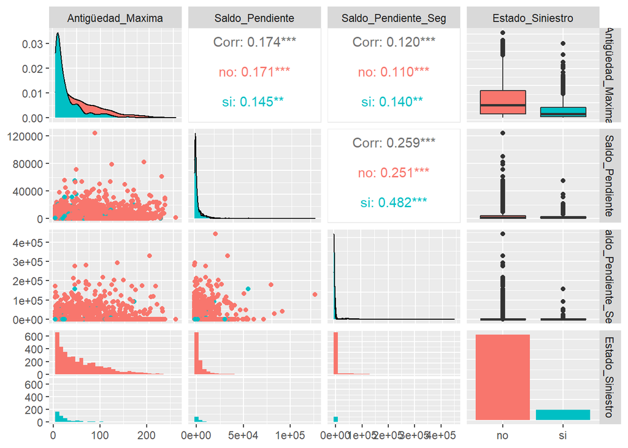

```r
ggpairs(data_seguros_ok[,c("Antigüedad_Maxima", "Saldo_Pendiente", "Saldo_Pendiente_Seg", "Estado_Siniestro")], aes(colour=data_seguros_ok$Estado_Siniestro))
```

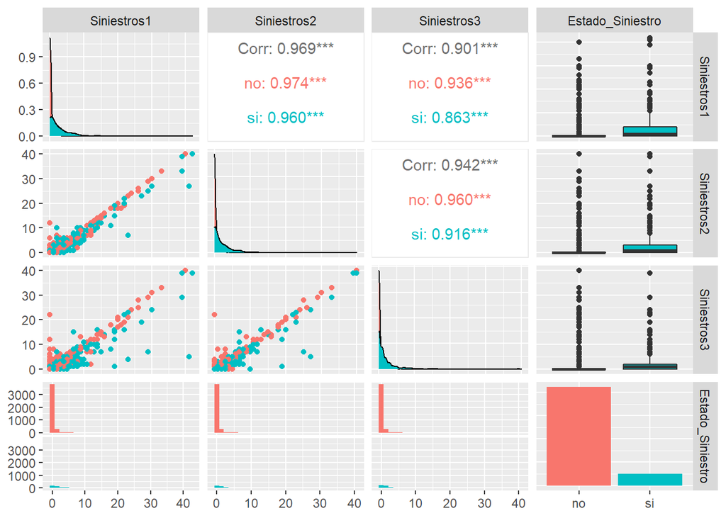

```r
ggpairs(data_seguros_ok[,c("Siniestros1", "Siniestros2", "Siniestros3", "Estado_Siniestro")], aes(colour=data_seguros_ok$Estado_Siniestro))
```

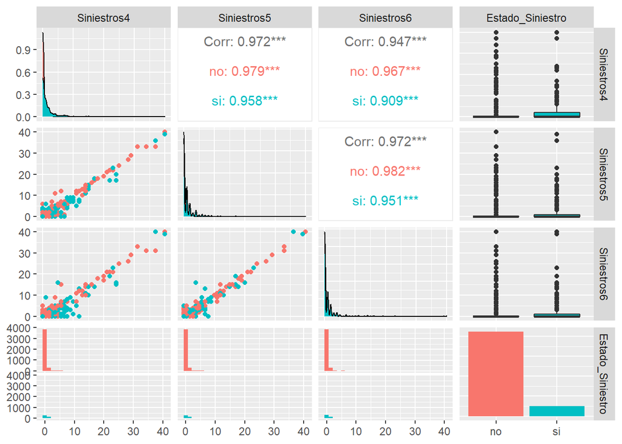

```r
ggpairs(data_seguros_ok[,c("Siniestros4", "Siniestros5", "Siniestros6", "Estado_Siniestro")], aes(colour=data_seguros_ok$Estado_Siniestro))
```

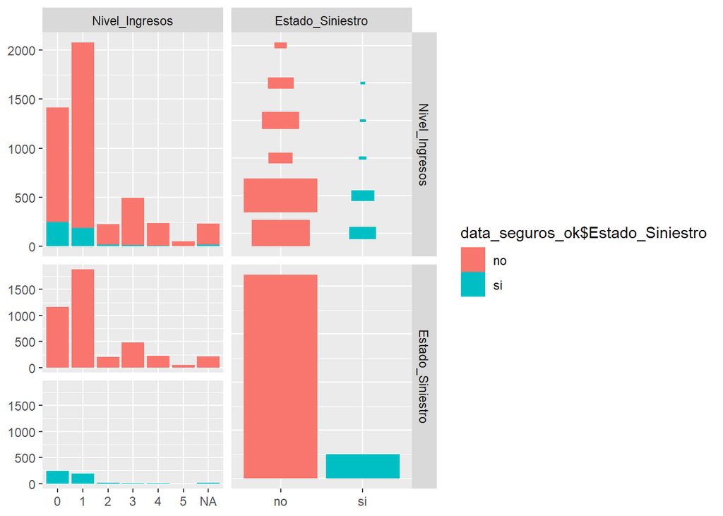

```r
ggpairs(data_seguros_ok[,c("Nivel_Ingresos", "Estado_Siniestro")], aes(colour=data_seguros_ok$Estado_Siniestro),legend = 2)
```

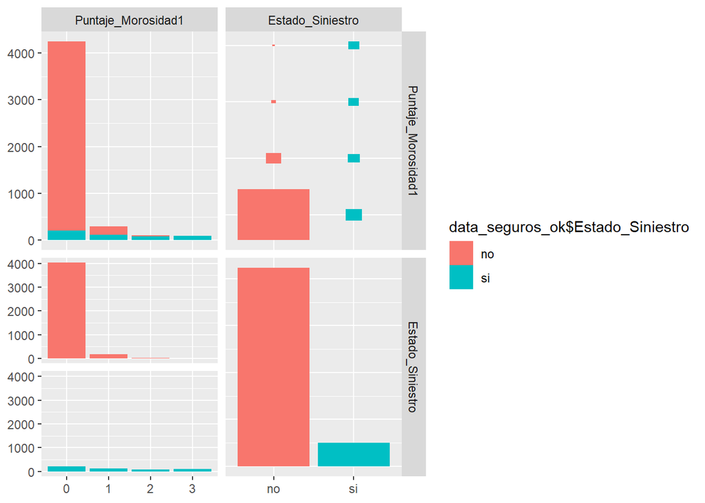

```r
ggpairs(data_seguros_ok[,c("Puntaje_Morosidad1", "Estado_Siniestro")], aes(colour=data_seguros_ok$Estado_Siniestro),legend = c(1,2))
```

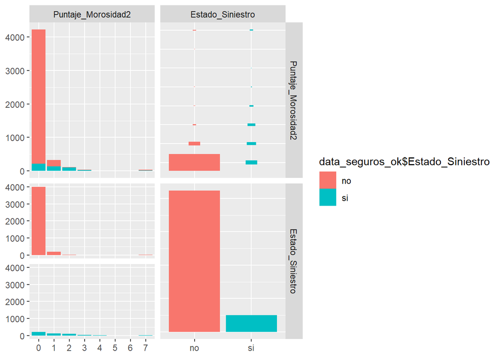

```r
ggpairs(data_seguros_ok[,c("Puntaje_Morosidad2", "Estado_Siniestro")], aes(colour=data_seguros_ok$Estado_Siniestro),legend = c(1,2))
```

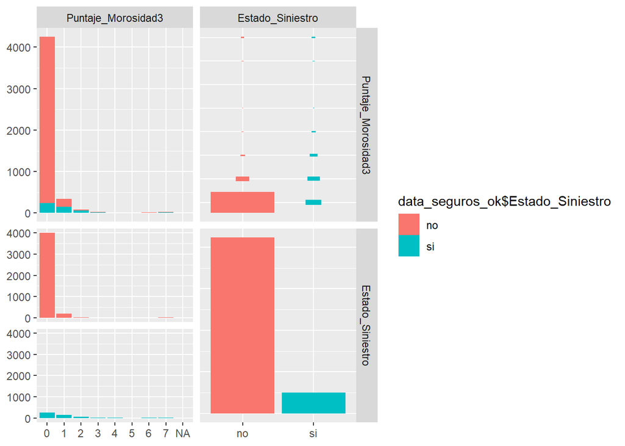

```r
ggpairs(data_seguros_ok[,c("Puntaje_Morosidad3", "Estado_Siniestro")], aes(colour=data_seguros_ok$Estado_Siniestro),legend = c(1,2))
```

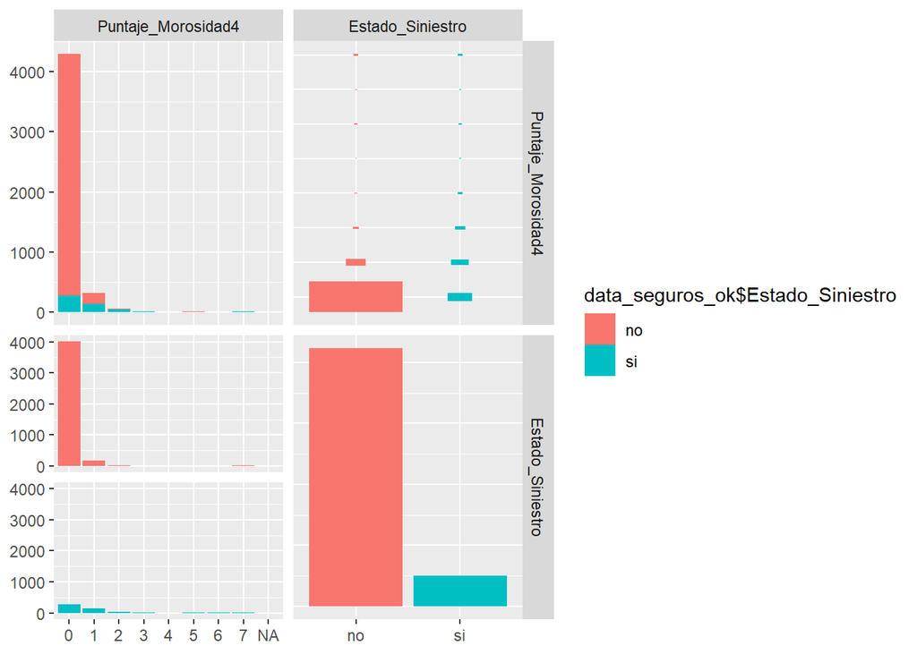

```r
ggpairs(data_seguros_ok[,c("Puntaje_Morosidad4", "Estado_Siniestro")], aes(colour=data_seguros_ok$Estado_Siniestro),legend = c(1,2))
```

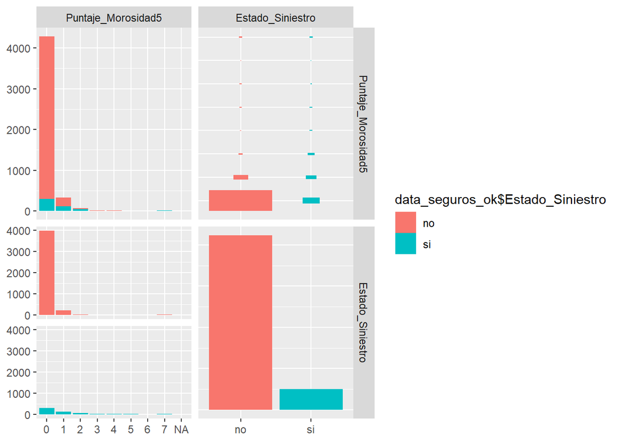

```r
ggpairs(data_seguros_ok[,c("Puntaje_Morosidad5", "Estado_Siniestro")], aes(colour=data_seguros_ok$Estado_Siniestro),legend = c(1,2))
```

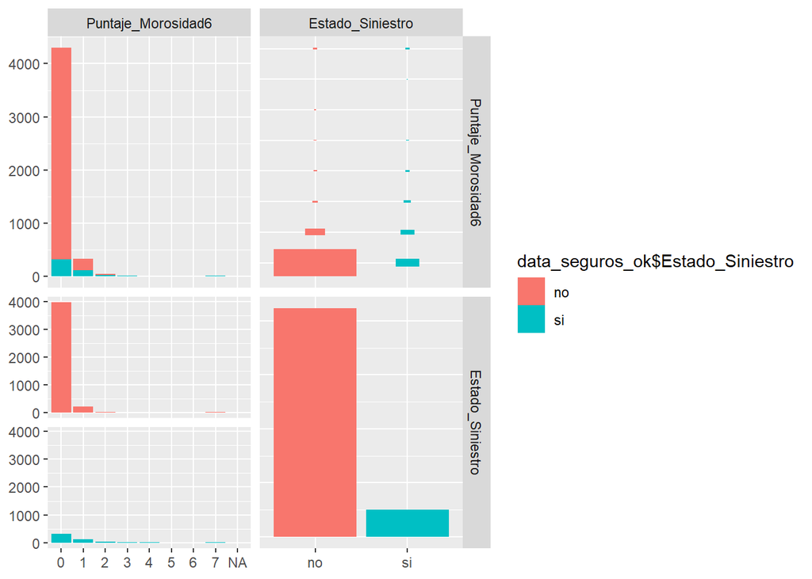

```r
ggpairs(data_seguros_ok[,c("Puntaje_Morosidad6", "Estado_Siniestro")], aes(colour=data_seguros_ok$Estado_Siniestro),legend = c(1,2))
```

### Aplicar Estadística Inferencial

# 1: La antiguedad Maxima es mayor en clientes que presentan siniestralidad con respecto de los que no presentan siniestralidad

Se observa datos outliers en la variable Antigüedad Maxima

Se analiza la distribucion de los valores de Antiguedad Maxima Observando: que no tienen distribución normal y es asimetrica hacia la derecha Por tanto, es pertinente analizar los outliers y se realizará a traves del diagrama de cajas

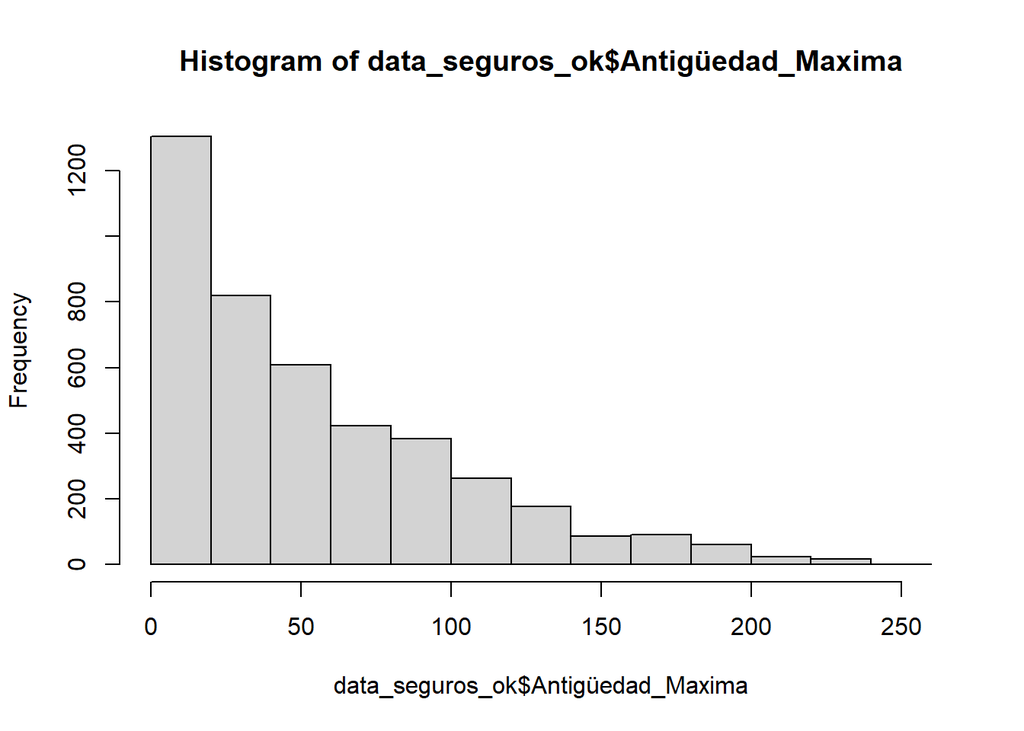

```r
hist(data_seguros_ok$Antigüedad_Maxima)
```

# A fin de analizar la distribución de los outliers se utilizará el diagrama de cajas (de forma horizontal)

Se observan datos fuera de bigote derecho

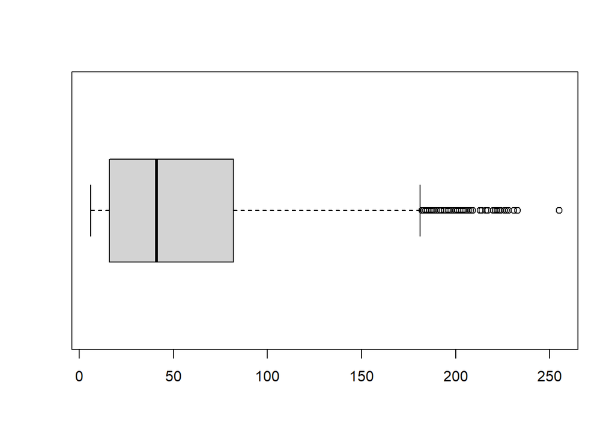

```r
boxplot(data_seguros_ok$Antigüedad_Maxima, horizontal=TRUE)
```

Se obtiene la lista de valores de los datos outliers a traves de la funcion boxplot.stats

```r
boxplot.stats(data_seguros_ok$Antigüedad_Maxima)
```

```
## $stats
## [1]   6  16  41  82 181
##
## $n
## [1] 4250
##
## $conf
## [1] 39.40042 42.59958
##
## $out
##  [1] 183 220 255 190 190 201 203 201 182 189 201 192 223 204 192 213 202 183 214
## [20] 216 209 199 194 224 189 184 217 217 186 221 205 183 224 194 191 196 183 194
## [39] 199 190 208 184 200 184 186 202 190 201 228 209 186 224 188 227 183 182 197
## [58] 196 227 184 231 217 186 187 186 191 191 195 189 190 185 228 196 185 191 186
## [77] 190 208 196 233 223 190 233 194 222 204 194 214 198 197 207 233 187 206 191
## [96] 226 190
```

Se obtiene datos del boxplot

LOS VALORES DE CORTE DE LA CAJA ($stats) [1] 6 16 41 82 181

Bigote inferior = 6 Limite inferior = 16 Mediana de los datos de Antiúedad Maxima= 41 Limite Superior = 82 Bigote Superior = 181

CANTIDAD DE DATOS ($n) [1] 4250

INTERVALO DE CONFIANZA AL 95% CONFIANZA PARA LA MEDIANA $conf [1] 39.40042 42.59958

LISTA DE VALORES OUTLIERS Con 97 valores Siendo el mínimo valor de 182 y maximo de 255

$out [1] 183 220 255 190 190 201 203 201 182 189 201 [12] 192 223 204 192 213 202 183 214 216 209 199 [23] 194 224 189 184 217 217 186 221 205 183 224 [34] 194 191 196 183 194 199 190 208 184 200 184 [45] 186 202 190 201 228 209 186 224 188 227 183 [56] 182 197 196 227 184 231 217 186 187 186 191 [67] 191 195 189 190 185 228 196 185 191 186 190 [78] 208 196 233 223 190 233 194 222 204 194 214 [89] 198 197 207 233 187 206 191 226 190

Se procede a obtener una lista de valores que no son outliers.  
Se observa que la variable Antigüedad_Maxima, tiene datos nulos

Se procede en la variable Antigüedad_Maxima Retirar los datos outliers Retirar los datos nuelos

```r
# Retirando los datos outlier
data_seguros_ok_sin_out <- data_seguros_ok[data_seguros_ok$Antigüedad_Maxima<182,]

# Retirando los datos nulos
# Se crea una nueva data sin nulos y outlier
data_seguros_sin_out_null_AntMax <- data_seguros_ok_sin_out[is.na(data_seguros_ok_sin_out$Antigüedad_Maxima) == FALSE, ]

str(data_seguros_sin_out_null_AntMax)
```

```
## 'data.frame':    4153 obs. of  18 variables:
##  $ Cliente_ID         : chr  "185" "238" "346" "549" ...
##  $ Antigüedad_Maxima  : int  44 79 102 109 172 76 136 171 93 119 ...
##  $ Nivel_Ingresos     : Factor w/ 6 levels "0","1","2","3",..: 2 2 2 NA 1 2 1 1 2 2 ...
##  $ Saldo_Pendiente    : num  605 1006 299 218 3517 ...
##  $ Puntaje_Morosidad1 : Factor w/ 7 levels "0","1","2","3",..: 1 1 1 1 1 1 1 1 1 1 ...
##  $ Puntaje_Morosidad2 : Factor w/ 8 levels "0","1","2","3",..: 1 1 1 1 1 1 1 1 1 1 ...
##  $ Puntaje_Morosidad3 : Factor w/ 8 levels "0","1","2","3",..: 1 1 1 1 1 2 1 1 1 1 ...
##  $ Puntaje_Morosidad4 : Factor w/ 8 levels "0","1","2","3",..: 1 1 1 1 1 1 1 1 1 1 ...
##  $ Puntaje_Morosidad5 : Factor w/ 8 levels "0","1","2","3",..: 1 1 1 1 1 1 1 1 1 1 ...
##  $ Puntaje_Morosidad6 : Factor w/ 8 levels "0","1","2","3",..: 1 1 1 1 1 1 1 1 1 1 ...
##  $ Saldo_Pendiente_Seg: num  0 0 0 0 0 0 0 0 0 0 ...
##  $ Siniestros1        : int  0 0 0 0 0 0 0 0 0 0 ...
##  $ Siniestros2        : int  0 0 0 0 0 0 0 0 0 0 ...
##  $ Siniestros3        : int  0 0 0 0 0 0 0 0 0 0 ...
##  $ Siniestros4        : int  0 0 0 0 0 1 0 0 0 0 ...
##  $ Siniestros5        : int  0 0 0 0 0 1 0 0 0 0 ...
##  $ Siniestros6        : int  0 0 0 0 0 1 0 0 0 0 ...
##  $ Estado_Siniestro   : Factor w/ 3 levels "","no","si": 2 2 2 2 2 2 2 2 2 2 ...
```

```r
summary(data_seguros_sin_out_null_AntMax)
```

```
##   Cliente_ID        Antigüedad_Maxima Nivel_Ingresos Saldo_Pendiente
##  Length:4153        Min.   :  6.00    0   :1262      Min.   :     0.01
##  Class :character   1st Qu.: 16.00    1   :1828      1st Qu.:   465.53
##  Mode  :character   Median : 39.00    2   : 202      Median :  1274.28
##                     Mean   : 51.57    3   : 420      Mean   :  3537.16
##                     3rd Qu.: 78.00    4   : 189      3rd Qu.:  3785.68
##                     Max.   :181.00    5   :  43      Max.   :124102.08
##                                       NA's: 209
##  Puntaje_Morosidad1 Puntaje_Morosidad2 Puntaje_Morosidad3 Puntaje_Morosidad4
##  0:3713             0      :3691       0      :3716       0      :3756
##  1: 264             1      : 290       1      : 303       1      : 290
##  2:  92             2      : 106       2      :  76       2      :  56
##  3:  84             3      :  31       7      :  24       7      :  20
##  4:   0             7      :  28       3      :  20       3      :  12
##  5:   0             4      :   5       (Other):  13       (Other):  16
##  6:   0             (Other):   2       NA's   :   1       NA's   :   3
##  Puntaje_Morosidad5 Puntaje_Morosidad6 Saldo_Pendiente_Seg  Siniestros1
##  0      :3744       0      :3768       Min.   :     0      Min.   : 0.0000
##  1      : 300       1      : 296       1st Qu.:     0      1st Qu.: 0.0000
##  2      :  61       2      :  43       Median :     0      Median : 0.0000
##  7      :  18       7      :  18       Mean   :  5148      Mean   : 0.6547
##  3      :  10       3      :  13       3rd Qu.:     0      3rd Qu.: 0.0000
##  (Other):  16       (Other):  11       Max.   :292057      Max.   :42.0000
##  NA's   :   4       NA's   :   4
##   Siniestros2       Siniestros3       Siniestros4       Siniestros5
##  Min.   : 0.0000   Min.   : 0.0000   Min.   : 0.0000   Min.   : 0.0000
##  1st Qu.: 0.0000   1st Qu.: 0.0000   1st Qu.: 0.0000   1st Qu.: 0.0000
##  Median : 0.0000   Median : 0.0000   Median : 0.0000   Median : 0.0000
##  Mean   : 0.5692   Mean   : 0.5098   Mean   : 0.4777   Mean   : 0.4327
##  3rd Qu.: 0.0000   3rd Qu.: 0.0000   3rd Qu.: 0.0000   3rd Qu.: 0.0000
##  Max.   :40.0000   Max.   :40.0000   Max.   :40.0000   Max.   :40.0000
##
##   Siniestros6      Estado_Siniestro
##  Min.   : 0.0000     :   0
##  1st Qu.: 0.0000   no:3706
##  Median : 0.0000   si: 447
##  Mean   : 0.3944
##  3rd Qu.: 0.0000
##  Max.   :40.0000
##
```

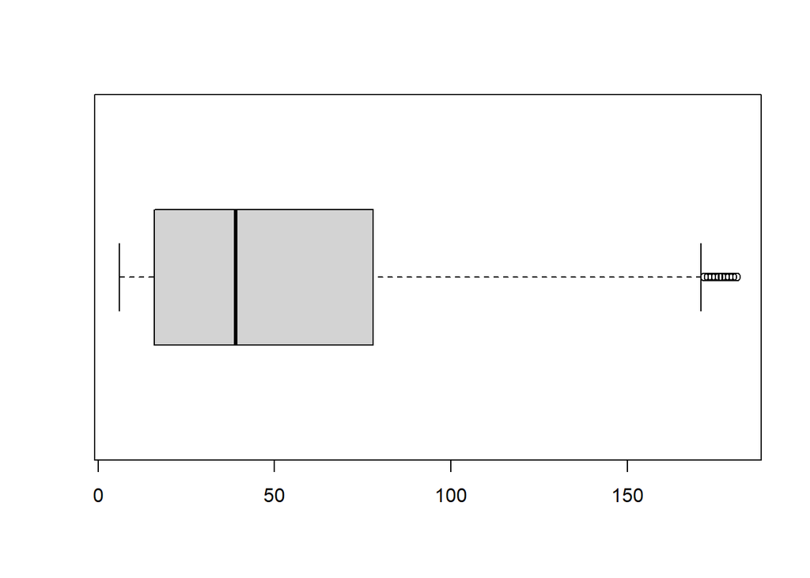

```r
View(data_seguros_sin_out_null_AntMax )
boxplot(data_seguros_sin_out_null_AntMax$Antigüedad_Maxima, horizontal=TRUE)
```

# Retirando los datos outlier En el nuevo conjunto de datos “data_seguros_sin_out_null_AntMax” Se repetiran los pasos anteriores

Se obtiene la lista de valores de los datos outliers a traves de la funcion boxplot.stats

```r
boxplot.stats(data_seguros_sin_out_null_AntMax$Antigüedad_Maxima)
```

```
## $stats
## [1]   6  16  39  78 171
##
## $n
## [1] 4153
##
## $conf
## [1] 37.47992 40.52008
##
## $out
##  [1] 172 178 172 180 178 173 175 173 178 176 175 179 181 181 181 172 173 176 177
## [20] 174 180 176 181 172 178 179 175 177 175 172 174 172 176 175 176
```

#Se obtiene datos del boxplot

LOS VALORES DE CORTE DE LA CAJA ($stats) [1] 6 16 39 78 171

Bigote inferior = 6 Limite inferior = 16 Mediana de los datos de Antiúedad Maxima= 39 Limite Superior = 78 Bigote Superior = 171

CANTIDAD DE DATOS ($n) [1] 4153

INTERVALO DE CONFIANZA AL 95% CONFIANZA PARA LA MEDIANA $conf [1] 37.47992 40.52008

LISTA DE VALORES OUTLIERS Con 35 valores Siendo el mínimo valor de 172 y maximo de 181

$out [1] 172 178 172 180 178 173 175 173 178 176 175 179 181 181 181 172 173 176 177 [20] 174 180 176 181 172 178 179 175 177 175 172 174 172 176 175 176

#Se procede a obtener una lista de valores que no son outliers.

#Se procede en la variable Antigüedad_Maxima #Retirar los datos outliers

```r
# Retirando los datos outlier
data_seguros_sin_out_null_AntMax <- data_seguros_sin_out_null_AntMax[data_seguros_sin_out_null_AntMax$Antigüedad_Maxima<172,]
```

# A fin de analizar la distribución de los outliers se utilizará el diagrama de cajas (de forma horizontal)

Se observan datos fuera de bigote derecho

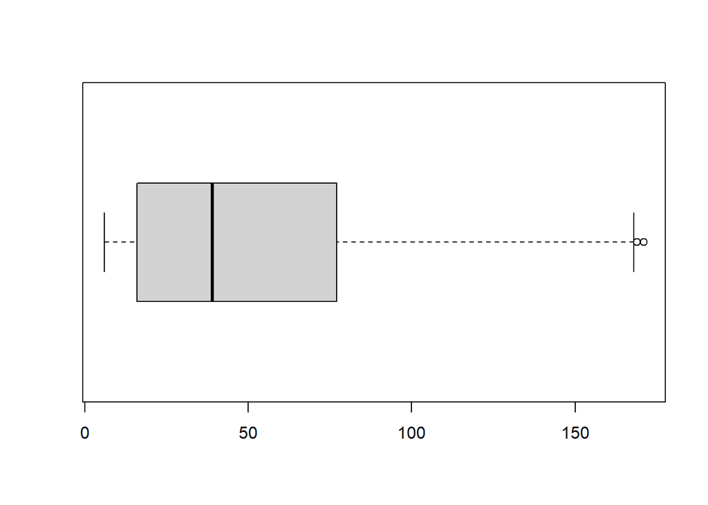

```r
boxplot(data_seguros_sin_out_null_AntMax$Antigüedad_Maxima, horizontal=TRUE)
```

```r
boxplot.stats(data_seguros_sin_out_null_AntMax$Antigüedad_Maxima)
```

```
## $stats
## [1]   6  16  39  77 168
##
## $n
## [1] 4118
##
## $conf
## [1] 37.49809 40.50191
##
## $out
## [1] 171 169 171 169 171 169 169 169
```

#Se obtiene datos del boxplot

LOS VALORES DE CORTE DE LA CAJA ($stats) [1] 6 16 39 77 168

Bigote inferior = 6 Limite inferior = 16 Mediana de los datos de Antiúedad Maxima= 39 Limite Superior = 77 Bigote Superior = 168

CANTIDAD DE DATOS ($n) [1] 4118

INTERVALO DE CONFIANZA AL 95% CONFIANZA PARA LA MEDIANA $conf [1] 37.49809 40.50191

LISTA DE VALORES OUTLIERS Con 8 valores Siendo el mínimo valor de 169 y maximo de 171

$out [1] 171 169 171 169 171 169 169 169

#Se procede a obtener una lista de valores que no son outliers.

#Se procede en la variable Antigüedad_Maxima #Retirar los datos outliers

```r
# Retirando los datos outlier
data_seguros_sin_out_null_AntMax <- data_seguros_sin_out_null_AntMax[data_seguros_sin_out_null_AntMax$Antigüedad_Maxima<169,]
```

# De nuevo a fin de analizar la distribución de los outliers se utilizará el diagrama de cajas (de forma horizontal)

# NO se observan datos fuera de bigote derecho e izquierdo

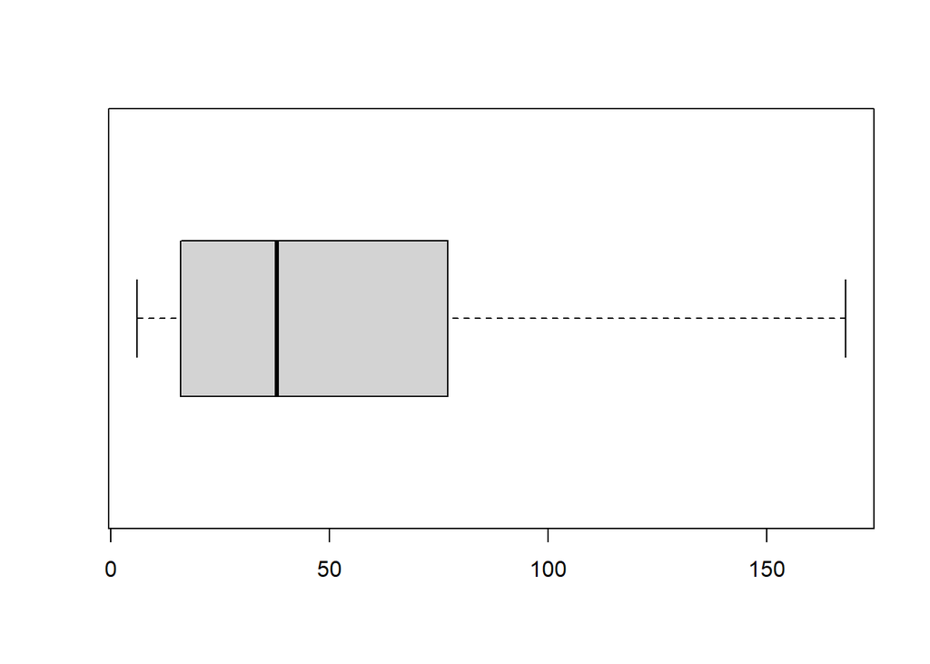

```r
boxplot(data_seguros_sin_out_null_AntMax$Antigüedad_Maxima, horizontal=TRUE)
```

# Una vez obtenida la data preaprada sin outlier con respecto a la variable Antigüedad_Maxima # permitirá hacer la inferencia estadística

# Hipotesis par acomparcion de medias del Antiguedad Maxima segun el presencia o ausencia de sieniestralidad

# 1: Ho:La Antiguedad Maxima es mayor en clientes que presentan siniestralidad con respecto de los no presentan siniestralidad

```
 H1:La Antiguedad Maxima es menor en clientes que presentan siniestralidad con respecto de los no presentan siniestralidad
```

# se verifica la normalidad de la variable

HIPÓTESIS

Ho: Los datos de la variables Antigüedad_Maxima estan normalmente distribuidos  
Ha: Los datos de la variables Antigüedad_Maxima no estan normalmente distribuidos

Nivel de significancia = 5% (0.05)

```r
# Test: Kolmogorov-Smirnov "para la prueba de normalidad, n>50 casos"
library(nortest)
lillie.test(data_seguros_sin_out_null_AntMax$Antigüedad_Maxima)$p.value  # $p.value =  muestrame el p_value
```

```
## [1] 4.587369e-215
```

Se obsera un p_value <0.05

Decisión: Los datos de la variables “Antigüedad_Maxima” NO están normalmente distribuidos; esto afirmamos con un nivel de confianza del 95% / nivel de significancia del 5%.

data_seguros_ok_sin_out <- data_seguros_ok[data_seguros_ok$Antigüedad_Maxima<182,]

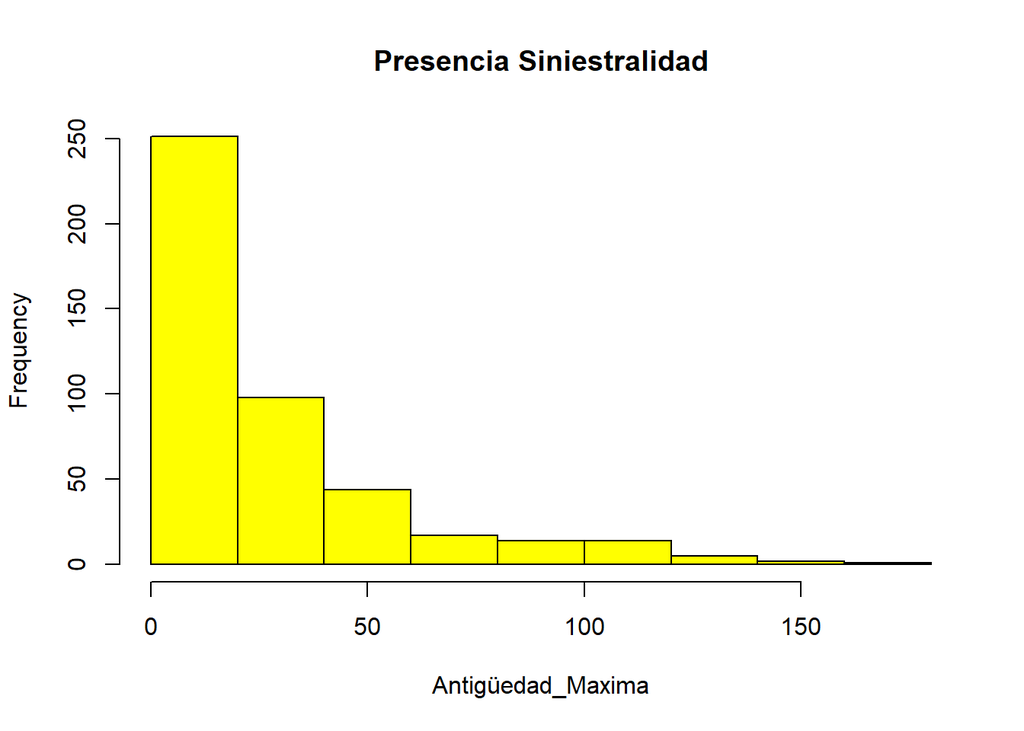

```r
data_seguros_sin_out_null_AntMax_ES_si <- data_seguros_sin_out_null_AntMax[data_seguros_sin_out_null_AntMax$Estado_Siniestro=="si", ]

#str(data_seguros_sin_out_null_AntMax_ES_si)

data_seguros_sin_out_null_AntMax_ES_no <- data_seguros_sin_out_null_AntMax[data_seguros_sin_out_null_AntMax$Estado_Siniestro=="no", ]

#str(data_seguros_sin_out_null_AntMax_ES_no)


hist(data_seguros_sin_out_null_AntMax_ES_si$Antigüedad_Maxima, main = "Presencia Siniestralidad", xlab = "Antigüedad_Maxima",col = "yellow")
```

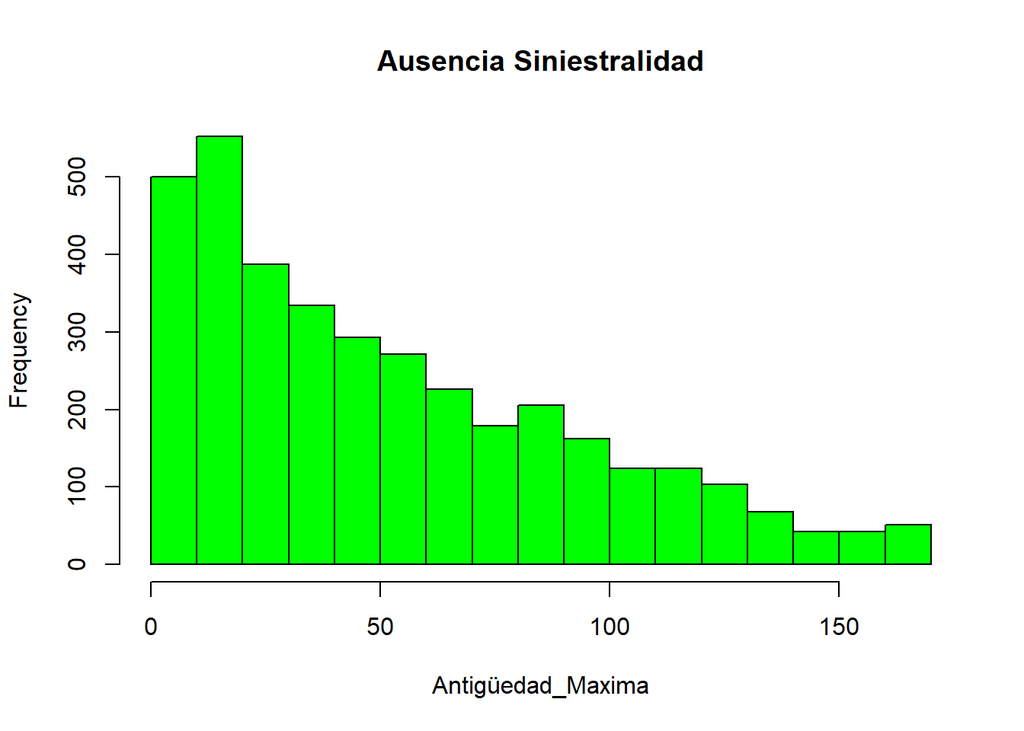

```r
hist(data_seguros_sin_out_null_AntMax_ES_no$Antigüedad_Maxima, main = "Ausencia Siniestralidad", xlab = "Antigüedad_Maxima",col = "green")
```

```r
wilcox.test(x = data_seguros_sin_out_null_AntMax_ES_si$Antigüedad_Maxima, y = data_seguros_sin_out_null_AntMax_ES_no$Antigüedad_Maxima, alternative = "less", mu = 0, paired = FALSE)
```

```
##
##  Wilcoxon rank sum test with continuity correction
##
## data:  data_seguros_sin_out_null_AntMax_ES_si$Antigüedad_Maxima and data_seguros_sin_out_null_AntMax_ES_no$Antigüedad_Maxima
## W = 508445, p-value < 2.2e-16
## alternative hypothesis: true location shift is less than 0
```

DECISION existencia evidencias estadisticas para afirmar que la Antiguedad Maxima es menor en clientes que presentan siniestralidad con respecto de los no presentan siniestralidad

En promedio los clientes antiguos no presenta sinietsatralidad